# DATA 606 Class Presentation

Samuel I Kigamba

December 11, 2019

# 8.31 Body measurements, Part IV.

The scatterplot and least squares summary below show the relationship between weight measured in kilograms and height measured in centimeters of 507 physically active individuals.

```r
library(XML)
library(RCurl)
library(dplyr)
library(plyr)
library(tidyr)
```

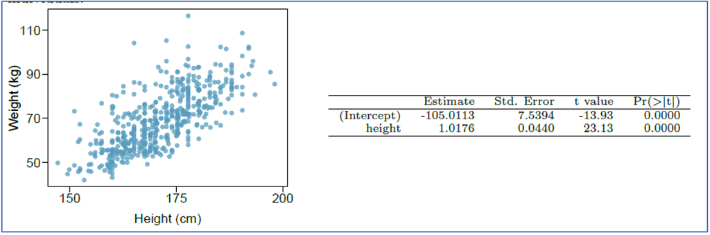

```r
library(plotly)
library(tidyverse)
library(tidyselect)
library(data.table)
#install.packages('png')
library(htmltools)
library(png)
```

```r
#imgage <- "WeightHeight.png"
#include_graphics(imgage)
```

1. Describe the relationship between height and weight.

From the scatterplot above there seems to be a positive relationship between Height and Weight.

2. Write the equation of the regression line. Interpret the slope and intercept in context.

$$Weight = -105.0113 + 1.0176 X Height +- SE$$

3. Do the data provide strong evidence that an increase in height is associated with an increase in weight?

Yes: The data provides strong evidence that an increease in height is associated with an increase in weight.

```r
Weight1h = -105.0113 + 1.0176 * 160 + 7.5394
Weight1l = -105.0113 + 1.0176 * 160 - 7.5394
print(c(Weight1l, Weight1h))
```

```
## [1] 50.2653 65.3441
```

```r
Weight2h = -105.0113 + 1.0176 * 175 + 7.5394
Weight2l = -105.0113 + 1.0176 * 175 - 7.5394
print(c(Weight2l, Weight2h))
```

```
## [1] 65.5293 80.6081
```

```r
Weight3h = -105.0113 + 1.0176 * 190 + 7.5394
Weight3l = -105.0113 + 1.0176 * 190 - 7.5394
print(c(Weight3l, Weight3h))
```

```
## [1] 80.7933 95.8721
```

State the null and alternative hypotheses, report the p-value, and state your conclusion.

H_0 : There is no relationship between weight and height.

H_A : There is a relationship between weight and height.

The P-value is so small that we reject the null hypothesis and conclude that there is a relationship between height and weight. Height and weight are positively correlated and the true slope is greater than zero.

4. The correlation coefficient for height and weight is 0.72. Calculate R2 and interpret it in context.

```r
#imgage <- "Correlation.png"
#include_graphics(imgage)
```

The R^2 of a linear model describes the amount of variation in the response that is explained by the least squares line. This can also be interpreted as how closely the data cluster around the linear fit.

```r
R = 0.72
R_Sqrd = R^2
R_Sqrd
```

```
## [1] 0.5184
```

In this case 51.84% of the variation is explained by the linear model.